# DATA607_Week3

Logan Thomson

February 13, 2016

### Setting Up Database Connection

After setting up the tables in SQL, we can use the `RMySQL` package to connect to the MySQL database and use an SQL script just as we would in MySQL.

```r
library('RMySQL')
drv <- dbDriver('MySQL')
con <- dbConnect(drv, user="root", password="", dbname = "tb",
                 host = "localhost")
```

Using the combination of the MySQL driver stored in `drv` and the database connection, stored in `con`, we can view the tables in our database

```r
dbListTables(con)
```

```
## [1] "population" "tb"         "tb_cases"
```

As well as view the fields in a particular table

```r
dbListFields(con, "tb")
```

```
## [1] "country" "year"    "sex"     "child"   "adult"   "elderly"
```

#### Querying the Database

Following is the code that does most of the work. This is the same `SELECT` statement that wold retrieve the data from each table and combine it together to return the data. The SQL script is stored in the `query` object.

```r
query <- "SELECT t.country, t.year, sum(t.cases) AS cases, p.population,
(t.cases / p.population) * 1000 AS rate
FROM tb_cases AS t
INNER JOIN population AS p
ON p.country = t.country
AND p.year = t.year
WHERE cases is not null
GROUP BY t.country, t.year"

cases_per_1000 <- dbGetQuery(con, query)
```

Using `dbGetQuery` and calling our `con` connection object and the SQL script stored in `query`, we can store the retrieved data in an object, which I have called `cases_per_1000`. Because the rate returned by dividing cases by population was small, I used a multiple to return a more managable number.

```r
dbDisconnect(con)
```

```
## [1] TRUE
```

```r
dbUnloadDriver(drv)
```

```
## [1] TRUE
```

### Creating Data Frame

To manipulate the data in R, the returned SQL data can be stored in a data frame, which I have called `cases_df`. Below is a preview of the first few rows:

```r
cases_df <- data.frame(cases_per_1000)
head(cases_df)
```

```
##       country year cases population   rate
## 1 Afghanistan 1997   128   19021226 0.0054
## 2 Afghanistan 1998  1778   19496836 0.0619
## 3 Afghanistan 1999   745   19987071 0.0259
## 4 Afghanistan 2000  2666   20595360 0.0850
## 5 Afghanistan 2001  4639   21347782 0.1434
## 6 Afghanistan 2002  6509   22202806 0.1990
```

And here are the summary statistics for the data:

```r
summary(cases_df)
```

```
##    country               year          cases           population
##  Length:1691        Min.   :1995   Min.   :      0   Min.   :6.759e+05
##  Class :character   1st Qu.:2000   1st Qu.:   2800   1st Qu.:8.842e+06
##  Mode  :character   Median :2005   Median :   6515   Median :2.014e+07
##                     Mean   :2004   Mean   :  25208   Mean   :6.387e+07
##                     3rd Qu.:2009   3rd Qu.:  15266   3rd Qu.:4.868e+07
##                     Max.   :2013   Max.   :1198289   Max.   :1.386e+09
##       rate
##  Min.   :0.0000
##  1st Qu.:0.0656
##  Median :0.1361
##  Mean   :0.2461
##  3rd Qu.:0.2851
##  Max.   :4.0372
```

### Plotting Data

Lets make a quick histogram of the rate data to see what we are working with:

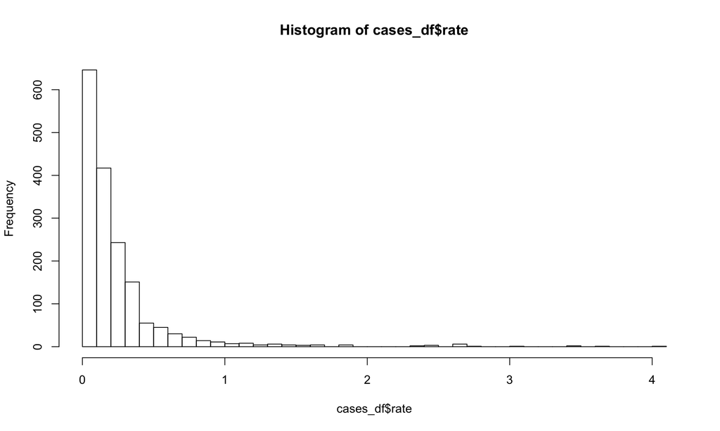

```r
hist(cases_df$rate, breaks=30)
```

In most years, countries have less than 1 case per 1000, and in more severe cases, there are several cases per 1000 people, which is a relatively high rate. Still, for the rates below 1 per 1000, there is a lot of variance.

Let’s take a look at two countries that greatly differ in their overall economies, the United States, and Angola (TB rates in Africa are generally higher than other parts of the world):

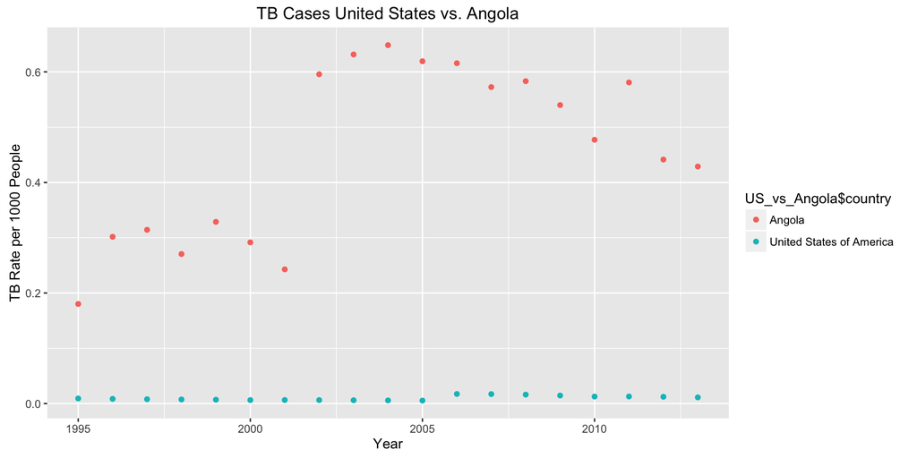

```r
library(ggplot2)
US_vs_Angola <- subset(cases_df, country == 'Angola'| country == 'United States of America')
ggplot(US_vs_Angola, aes(x=US_vs_Angola$year, y=US_vs_Angola$rate)) + geom_point(aes(color = US_vs_Angola$country)) + labs(title='TB Cases United States vs. Angola', x="Year", y="TB Rate per 1000 People")
```

Though both have rates that are below 1 case per 1000 people, the rate of TB cases in Angola is much higher than that of the rate in the United States, which is virtually zero.